# Trabajo 1 Geomarketing

Pedro Pablo Silva Antilef

7 de mayo de 2020

# Introducción

En este trabajo se analizará la base de datos de la Encuesta de Caracterización Socioeconomica Nacional (CASEN), específicamente de las variables Ingresos corregidos (ytotcor), Edad (edad), Años de escolaridad (esc) y finalmente el sexo de la persona encuestada. La idea es explorar la base de datos y limpiarla. Posteriormente se realizarán regresiones considerando los ingresos como la variable dependiente y los Años de Escolaridad y la Edad como variables independientes para las primeras regresiones. Para el segundo grupo de regresiones se adicionará al análisis la variable Sexo como dummy, donde el valor 1 corresponde a “Hombre” y el valor 2 corresponde a “Mujer”.

# Importación de datos

Se importan los datos desde BD Postgres que contiene todos los datos de la encuesta.

```r
library(caret)
library(psych)
library(RPostgreSQL)
library(dplyr)
library(ggplot2)
library(GGally)
library(randomForest)
library(rmarkdown)

#Conectar con dbpsql
#clave de acceso
pw = {
  "admin"
}
drv = dbDriver("PostgreSQL")

#Crear conexión a base de datos
con = dbConnect(drv, dbname = "postgres",
                host = "localhost", port = 5432,
                user = "postgres", password = "admin")

#Solicitud SQL data "general"
q = "SELECT ytotcor as ingreso, edad, esc, sexo, expc FROM public.casen;"
data = dbSendQuery(con, q)
data = dbFetch(data)
```

# Análisis exploratorio

Primero haremos un análisis exploratorio de las 3 variables consideradas en el estudio, para eso, veremos los headers del dataset, veremos los histogramas de cada variable en “crudo” y también los histogramas de las variables multiplicado por el factor de expansión comunal (expc).

Vemos los primeros registros del dataset

```r
head(data)
```

```
##   ingreso edad esc sexo expc
## 1  453667   31  16    2   18
## 2 1542000   33  18    1   18
## 3  943136   24  17    1   18
## 4 1338000   38  17    1   18
## 5  268000   27  17    2   18
## 6  483333   34  17    2   18
```

```r
summary(data)
```

```
##    ingreso              edad               esc
##  Length:35628       Length:35628       Length:35628
##  Class :character   Class :character   Class :character
##  Mode  :character   Mode  :character   Mode  :character
##      sexo               expc
##  Length:35628       Length:35628
##  Class :character   Class :character
##  Mode  :character   Mode  :character
```

## Histogramas

Los histogramas se analizarán con los datos en crudo y también utilizando el factor de expansión para ver la representatividad de la muestra.

### Histograma Ingreso sin factor de expansión

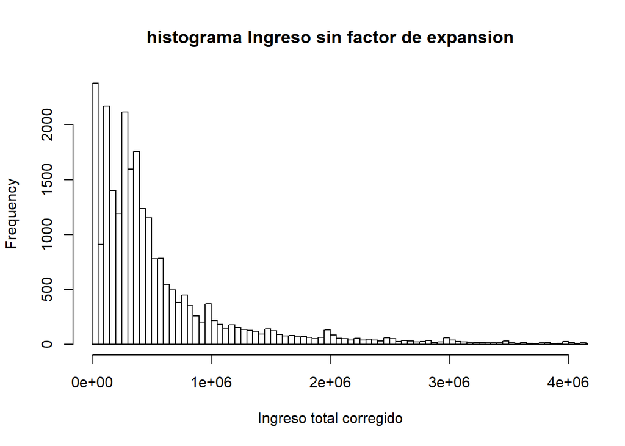

```r
data$ingreso = as.numeric(data$ingreso)
hist(data$ingreso, breaks = "FD",main = "histograma Ingreso sin factor de expansion", xlab = "Ingreso total corregido" ,xlim = c(0,4000000))
```

El histograma de ingreso se realizó sin considerar el factor de expansión y tiene una distribución esperada. Ya que la mayor frecuencia de sueldos se encuentra en sueldos bajos, donde la mayor frecuencia fluctua en valores menores al sueldo mínimo nacional.

### Histograma edad

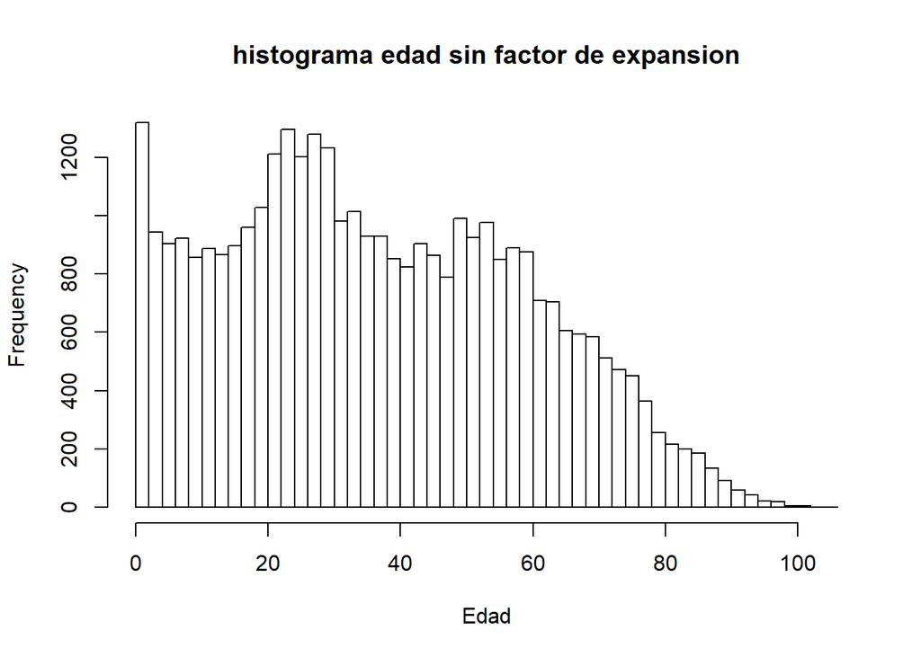

```r
#Histograma Edad sin factor de expansion
data$edad = as.numeric(data$edad)
hist(data$edad, breaks = "FD",main = "histograma edad sin factor de expansion", xlab = "Edad" )
```

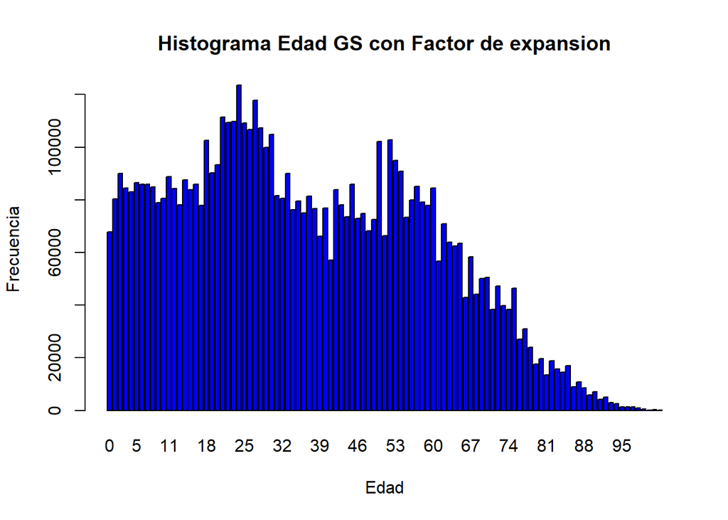

```r
#Histograma Edad con factor de expansion
q = "SELECT edad, COUNT(edad), SUM(CAST(expc AS DOUBLE PRECISION)) as Totedad FROM public.casen GROUP BY edad ORDER BY LENGTH(edad),edad;"
data_edad = dbSendQuery(con, q)
data_edad = dbFetch(data_edad)
barplot(data_edad$totedad,names.arg=data_edad$edad ,xlab="Edad",ylab="Frecuencia",col="blue",
        main="Histograma Edad GS con Factor de expansion",border="black")
```

Para el histograma de edad, se aprecia una pequeña diferencia en el histograma sin considerar el factor de expansión en cuanto al rango más pequeño, donde tiene una frecuencia considerablemente más alta que en el histograma considerando el factor de expansión. Esta alta frecuencia parece ser aplanada con el factor de expansión. El resto del histograma parece concordar con la situación poblacional de Chile, una población relativamente joven, que tiene a envejecer, situación demográfica típica de los paises en “vías de desarrollo”

### Histograma Escolaridad

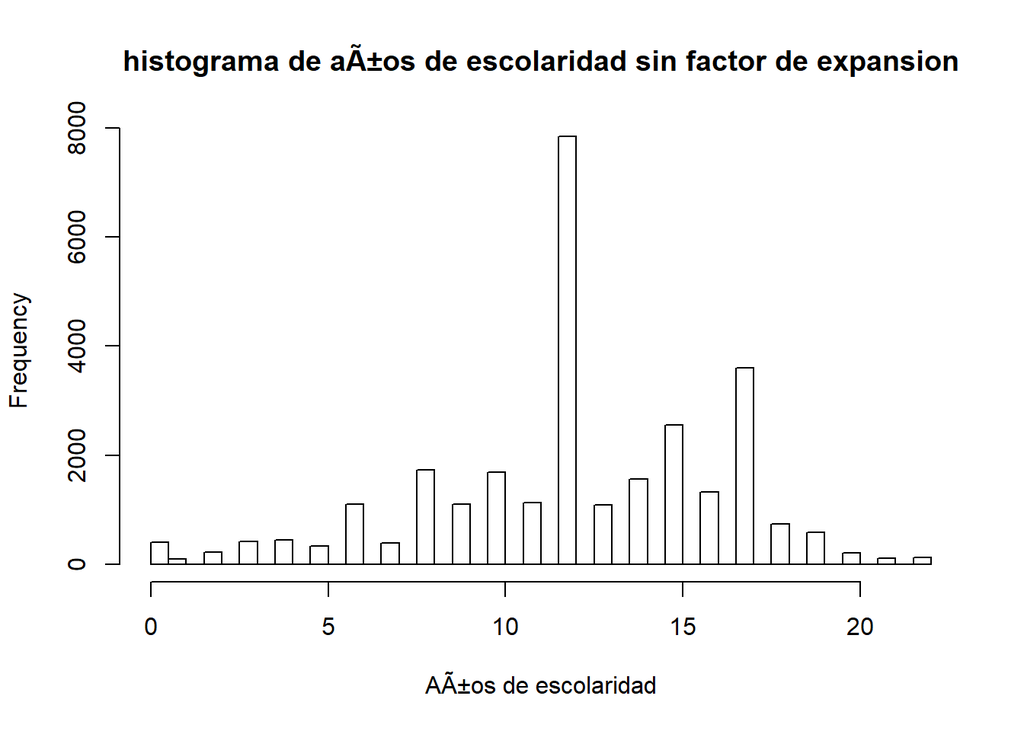

```r
#Histograma escolaridad sin factor de expansion
data$esc = as.numeric(data$esc)
hist(data$esc, breaks = "FD",main = "histograma de años de escolaridad sin factor de expansion", xlab = "Años de escolaridad")
```

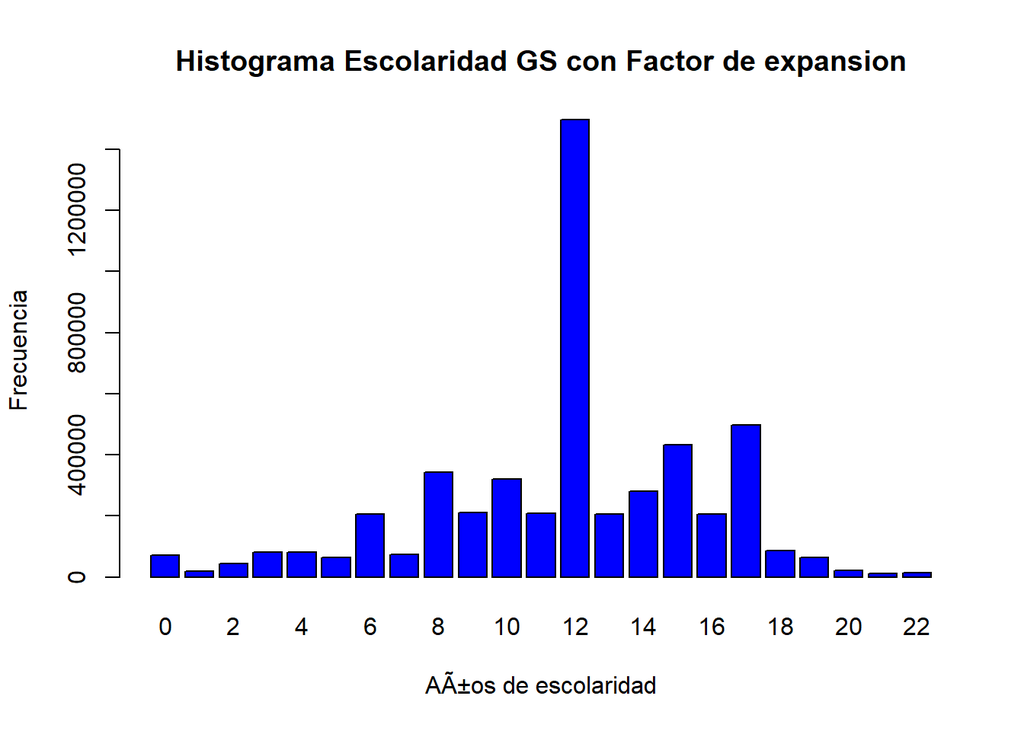

```r
#Histograma Escolaridad con factor de expansion
q = "SELECT esc, COUNT(esc), SUM(CAST(expc AS DOUBLE PRECISION)) as TotEsc FROM public.casen GROUP BY esc ORDER BY LENGTH(esc),esc;"
data_esc = dbSendQuery(con, q)
data_esc = dbFetch(data_esc)
data_esc = data_esc[-24,]
barplot(data_esc$totesc,names.arg=data_esc$esc  ,xlab="Años de escolaridad",ylab="Frecuencia",col="blue",
        main="Histograma Escolaridad GS con Factor de expansion",border="black")
```

Este es uno de los histogramas que presenta una mayor coherencia entre ambos histogramas. Se aprecia un peak de frecuencia en los 12 años de escolaridad, lo cual concuerda con los años de educación obligatoria del pais. La siguiente frecuencia más alta se encuentra en los 17 años de estudio, lo que equivaldría a una educación universitaria completa. El tercer peak corresponde a los 15 años de escolaridad, lo que correspondería a una carrera técnica profesional completa y cualquier otro estudio superior incompleta. Se considera que el valor 8, debería tener mayor frecuencia, ya que corresponde a la enseñanza básica completa y según el Censo población y vivienda 2017, este año debería tener una mayor frecuencia mayor, bastante parecida a la frecuencia de 17 años de escolaridad, se recomienda considerar una comparasión con dicha encuesta en un trabajo futuro.

## Depuración de datos y Matríz de correlación.

```r
#respaldar data
data_resp = data
#data = data_resp
# Separar datos en 70% de entrenamiento y 30% de prueba
data = data[c(1,2,3,4)]
data = data[complete.cases(data), ]
data = data[!(data$ingreso >10000000 | data$edad > 65 | data$esc <8 ),]
```

Para depurar nuestra base de datos, eliminamos aquellos registros que contienen datos como “NA”, disminuyendo de 35.628 registros a 17.652 observaciones. Además se eliminaron los outliers que generaban algunos subajustes en el modelamiento de los datos, como los ingresos superiores a 10 millones de pesos, mayores de 65 y personas que tengan menos de 8 años de escolaridad.

## Análisis de correlación

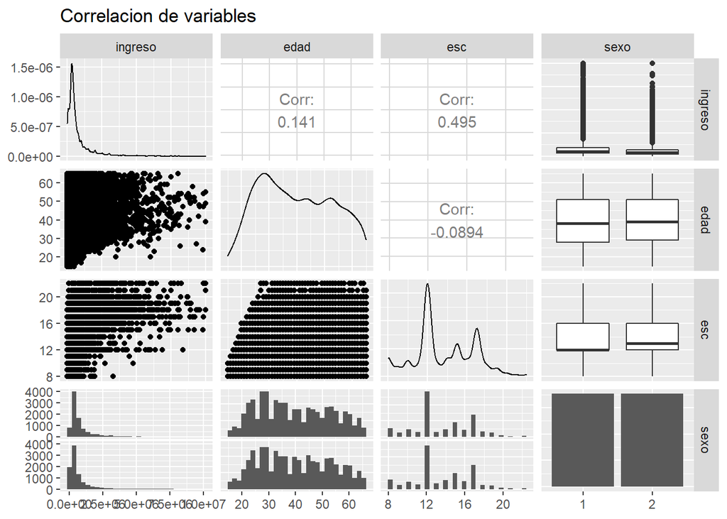

```r
ggpairs(data, title="Correlacion de variables")
```

Se procede a analizar la correlación entre las variables que se utilizarán. En la matríz de correlación podemos observar que la variable dependiente tiene una baja correlación con la edad (0.141), lo cual tiene sentido, ya que los ingresos no dependen de la edad de las personas, en general dependen de otros aspectos como los años de estudio, la calidad de la educación superior, si se tiene un trabajo formarl o informal, entre muchas otras variables, todas estas variables nombradas anteriormente no distinguen de edad.

Además es muy probable que el ingreso depende más de los años de estudios cursados y de la calidad de los estudios realizados. Los años de escolaridad tienen una correlación de 0.495, lo que demuestra que puede existir una relación positiva entre dichos años de estudio y los ingresos percividos por el individuo.

## Regresiones

Se decidió utilizar 3 tipos de regresiones para analizar nuestro dataset. Los modelos utilizados fueron: Regresión lineal de mínimos cuadrados Regresion lineal Elastic Net Regresión Random Forest

Para cada regresión se separó la muestra y se utilizó un 70% de los datos para entrenar los modelos y un 30% para la validación cruzada.

```r
set.seed(5)
ind = sample(2, nrow(data), replace = T, prob = c(0.7, 0.3))
train = data[ind==1,]
test = data[ind==2,]
```

### Regresión Ingreso = Años de escolaridad + Edad

#### Entrenamiento

Definimos los parámetros para entrenar las regresiones lineales, utilizando el método cv (Cross Validation)

```r
# Definir entrenamiento
param = trainControl(method = "cv",
                     number = 20,
                     repeats = 50)
```

#### Regresión lineal de mínimos cuadrados Sin Sexo

Finalmente generamos la regresión lineal de mínimos cuadrados y se muestran los resultados

```r
set.seed(1239)
lm = train(ingreso ~ esc + edad,
           train,
           method = 'lm',
           trControl = param)
lm
```

```
## Linear Regression
##
## 12323 samples
##     2 predictor
##
## No pre-processing
## Resampling: Cross-Validated (20 fold)
## Summary of sample sizes: 11707, 11706, 11707, 11707, 11707, 11708, ...
## Resampling results:
##
##   RMSE      Rsquared   MAE
##   821680.6  0.2772907  492911.9
##
## Tuning parameter 'intercept' was held constant at a value of TRUE
```

```r
summary(lm)
```

```
##
## Call:
## lm(formula = .outcome ~ ., data = dat)
##
## Residuals:
##      Min       1Q   Median       3Q      Max
## -1989489  -419097  -109750   199866  8370123
##
## Coefficients:
##               Estimate Std. Error t value Pr(>|t|)
## (Intercept) -1976748.7    42270.8  -46.76   <2e-16 ***
## esc           159923.8     2435.9   65.65   <2e-16 ***
## edad           13665.2      563.6   24.25   <2e-16 ***
## ---
## Signif. codes:  0 '***' 0.001 '**' 0.01 '*' 0.05 '.' 0.1 ' ' 1
##
## Residual standard error: 823500 on 12320 degrees of freedom
## Multiple R-squared:  0.2745, Adjusted R-squared:  0.2744
## F-statistic:  2331 on 2 and 12320 DF,  p-value: < 2.2e-16
```

De esta ecuación podemos inferir que por cada año más de escolaridad, en promedio los ingresos aumentan en 159923 pesos. De la misma manera, por cada año más de edad, los ingresos aumentan en promedio 13665, por lo que su influencia en la variale dependiente es menor que los años de escolaridad.

#### Regresión lineal con Elastic Net

Se genera la regresión lineal con el método Elastic Net

```r
set.seed(1237)
en = train(ingreso ~ esc + edad ,
           train,
           method = 'glmnet',
           tuneGrid = expand.grid(alpha = seq(0, 1, length = 10),
                                  lambda = seq(0.0001, 0.1, length = 5)),
           trControl = param)
en
```

```
## glmnet
##
## 12323 samples
##     2 predictor
##
## No pre-processing
## Resampling: Cross-Validated (20 fold)
## Summary of sample sizes: 11707, 11707, 11706, 11707, 11707, 11707, ...
## Resampling results across tuning parameters:
##
##   alpha      lambda    RMSE      Rsquared   MAE
##   0.0000000  0.000100  820885.1  0.2784361  487715.3
##   0.0000000  0.025075  820885.1  0.2784361  487715.3
##   0.0000000  0.050050  820885.1  0.2784361  487715.3
##   0.0000000  0.075025  820885.1  0.2784361  487715.3
##   0.0000000  0.100000  820885.1  0.2784361  487715.3
##   0.1111111  0.000100  820537.1  0.2784360  492131.8
##   0.1111111  0.025075  820537.1  0.2784360  492131.8
##   0.1111111  0.050050  820537.1  0.2784360  492131.8
##   0.1111111  0.075025  820537.1  0.2784360  492131.8
##   0.1111111  0.100000  820537.1  0.2784360  492131.8
##   0.2222222  0.000100  820537.1  0.2784360  492134.9
##   0.2222222  0.025075  820537.1  0.2784360  492134.9
##   0.2222222  0.050050  820537.1  0.2784360  492134.9
##   0.2222222  0.075025  820537.1  0.2784360  492134.9
##   0.2222222  0.100000  820537.1  0.2784360  492134.9
##   0.3333333  0.000100  820537.1  0.2784359  492142.9
##   0.3333333  0.025075  820537.1  0.2784359  492142.9
##   0.3333333  0.050050  820537.1  0.2784359  492142.9
##   0.3333333  0.075025  820537.1  0.2784359  492142.9
##   0.3333333  0.100000  820537.1  0.2784359  492142.9
##   0.4444444  0.000100  820537.2  0.2784358  492141.6
##   0.4444444  0.025075  820537.2  0.2784358  492141.6
##   0.4444444  0.050050  820537.2  0.2784358  492141.6
##   0.4444444  0.075025  820537.2  0.2784358  492141.6
##   0.4444444  0.100000  820537.2  0.2784358  492141.6
##   0.5555556  0.000100  820537.0  0.2784357  492167.8
##   0.5555556  0.025075  820537.0  0.2784357  492167.8
##   0.5555556  0.050050  820537.0  0.2784357  492167.8
##   0.5555556  0.075025  820537.0  0.2784357  492167.8
```

[output cut: 10 more lines]

```
##   0.7777778  0.100000  820537.3  0.2784353  492157.8
##   0.8888889  0.000100  820536.8  0.2784353  492200.0
##   0.8888889  0.025075  820536.8  0.2784353  492200.0
##   0.8888889  0.050050  820536.8  0.2784353  492200.0
##   0.8888889  0.075025  820536.8  0.2784353  492200.0
##   0.8888889  0.100000  820536.8  0.2784353  492200.0
##   1.0000000  0.000100  820537.3  0.2784351  492170.0
##   1.0000000  0.025075  820537.3  0.2784351  492170.0
##   1.0000000  0.050050  820537.3  0.2784351  492170.0
##   1.0000000  0.075025  820537.3  0.2784351  492170.0
##   1.0000000  0.100000  820537.3  0.2784351  492170.0
##
## RMSE was used to select the optimal model using the smallest value.
## The final values used for the model were alpha = 0.8888889 and lambda
##  = 0.1.
```

```r
tail(coef(en$finalModel), 3)
```

```
## [1] -1958403.41   159110.24    13482.98
```

$$\begin{align}
Ingresos = - 1958403 + 159110\cdot Esc + 13482\cdot Edad
\end{align}$$

La ecuación final de la regresión muestra que por cada año de escolaridad, los ingresos aumentan en 159110 promedio, mientras que por cada año más de edad, el ingreso aumenta en promedio 13482 pesos. En términos prácticos, el resultado es idéntico al obtenido en la regresión por mínimos cuadrados.

#### Regresión con Random Forest

Se redefinen los parámetros para el entrenamiento del algoritmo, cambiando el método cv por cv_adaptative, un método de validación cruzada adaptativa, para este tipo de algoritmos. Luego se hace correr el modelo con 1000 iteraciones.

```r
param = trainControl(method = "adaptive_cv",
                     number = 500)
rf = randomForest(log(ingreso) ~ esc + edad, data = train, trControl = param, ntree = 1000)
tail(rf$rsq)
```

```
## [1] 0.3727669 0.3727607 0.3727664 0.3727616 0.3727643 0.3727697
```

```r
rf
```

```
##
## Call:
##  randomForest(formula = log(ingreso) ~ esc + edad, data = train,      trControl = param, ntree = 1000)
##                Type of random forest: regression
##                      Number of trees: 1000
## No. of variables tried at each split: 1
##
##           Mean of squared residuals: 0.9625118
##                     % Var explained: 37.28
```

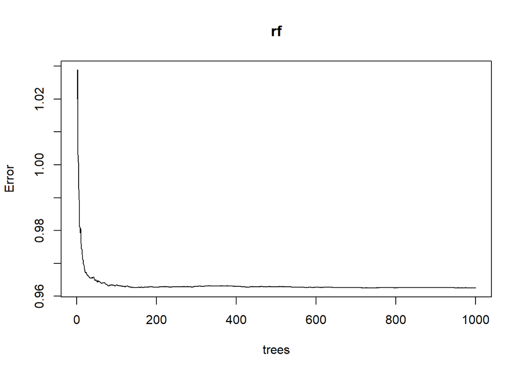

```r
plot(rf)
```

Este modelo no permite la interpretación de parámetros.

### Regresión Ingreso = Años de escolaridad + Edad + Sexo

Definimos los parámetros para entrenar las regresiones lineales, utilizando el método cv (Cross Validation)

```r
# Definir entrenamiento
param = trainControl(method = "cv",
                     number = 20,
                     repeats = 50)
```

#### Regresión lineal de mínimos cuadrados considerando sexo

Finalmente generamos la regresión lineal de mínimos cuadrados y se muestran los resultados

```r
set.seed(1999)
lm = train(ingreso ~ esc + edad + sexo,
           train,
           method = 'lm',
           trControl = param)
lm
```

```
## Linear Regression
##
## 12323 samples
##     3 predictor
##
## No pre-processing
## Resampling: Cross-Validated (20 fold)
## Summary of sample sizes: 11707, 11707, 11707, 11707, 11707, 11706, ...
## Resampling results:
##
##   RMSE      Rsquared   MAE
##   809261.3  0.2972032  487827.2
##
## Tuning parameter 'intercept' was held constant at a value of TRUE
```

```r
summary(lm)
```

```
##
## Call:
## lm(formula = .outcome ~ ., data = dat)
##
## Residuals:
##      Min       1Q   Median       3Q      Max
## -2122684  -411384  -108006   203025  8238679
##
## Coefficients:
##               Estimate Std. Error t value Pr(>|t|)
## (Intercept) -1856604.4    42305.4  -43.89   <2e-16 ***
## esc           160129.6     2406.0   66.56   <2e-16 ***
## edad           13809.7      556.7   24.81   <2e-16 ***
## sexo2        -257938.0    14656.5  -17.60   <2e-16 ***
## ---
## Signif. codes:  0 '***' 0.001 '**' 0.01 '*' 0.05 '.' 0.1 ' ' 1
##
## Residual standard error: 813400 on 12319 degrees of freedom
## Multiple R-squared:  0.2923, Adjusted R-squared:  0.2921
## F-statistic:  1696 on 3 and 12319 DF,  p-value: < 2.2e-16
```

Esta regresión obtuvo un R2 de 0.2972032, mostrando una leve mejora respecto a la misma regresión sin sexo, aun asi, sigue siendo una bondad de ajuste baja. Por otro lado el RMSE obtuvo un valor de 809261.3 La regresión quedó de la siguiete manera
$$\begin{align}
Ingresos = - 1856604 + 160129\cdot Esc + 13809\cdot Edad - 257938\cdot Sexo2
\end{align}$$

#### Regresión lineal con Elastic Net

Se genera la regresión lineal con el método Elastic Net

```r
set.seed(420)
en = train(ingreso ~ esc + edad + sexo,
           train,
           method = 'glmnet',
           tuneGrid = expand.grid(alpha = seq(0, 1, length = 10),
                                  lambda = seq(0.0001, 0.1, length = 5)),
           trControl = param)
en
```

```
## glmnet
##
## 12323 samples
##     3 predictor
##
## No pre-processing
## Resampling: Cross-Validated (20 fold)
## Summary of sample sizes: 11707, 11707, 11708, 11706, 11707, 11707, ...
## Resampling results across tuning parameters:
##
##   alpha      lambda    RMSE      Rsquared   MAE
##   0.0000000  0.000100  809921.8  0.2956591  482562.5
##   0.0000000  0.025075  809921.8  0.2956591  482562.5
##   0.0000000  0.050050  809921.8  0.2956591  482562.5
##   0.0000000  0.075025  809921.8  0.2956591  482562.5
##   0.0000000  0.100000  809921.8  0.2956591  482562.5
##   0.1111111  0.000100  809624.1  0.2956623  487001.3
##   0.1111111  0.025075  809624.1  0.2956623  487001.3
##   0.1111111  0.050050  809624.1  0.2956623  487001.3
##   0.1111111  0.075025  809624.1  0.2956623  487001.3
##   0.1111111  0.100000  809624.1  0.2956623  487001.3
##   0.2222222  0.000100  809624.3  0.2956621  487054.9
##   0.2222222  0.025075  809624.3  0.2956621  487054.9
##   0.2222222  0.050050  809624.3  0.2956621  487054.9
##   0.2222222  0.075025  809624.3  0.2956621  487054.9
##   0.2222222  0.100000  809624.3  0.2956621  487054.9
##   0.3333333  0.000100  809624.5  0.2956617  487049.3
##   0.3333333  0.025075  809624.5  0.2956617  487049.3
##   0.3333333  0.050050  809624.5  0.2956617  487049.3
##   0.3333333  0.075025  809624.5  0.2956617  487049.3
##   0.3333333  0.100000  809624.5  0.2956617  487049.3
##   0.4444444  0.000100  809624.7  0.2956612  487037.3
##   0.4444444  0.025075  809624.7  0.2956612  487037.3
##   0.4444444  0.050050  809624.7  0.2956612  487037.3
##   0.4444444  0.075025  809624.7  0.2956612  487037.3
##   0.4444444  0.100000  809624.7  0.2956612  487037.3
##   0.5555556  0.000100  809624.9  0.2956609  487054.9
##   0.5555556  0.025075  809624.9  0.2956609  487054.9
##   0.5555556  0.050050  809624.9  0.2956609  487054.9
##   0.5555556  0.075025  809624.9  0.2956609  487054.9
```

[output cut: 10 more lines]

```
##   0.7777778  0.100000  809625.3  0.2956605  487096.7
##   0.8888889  0.000100  809625.4  0.2956600  487069.6
##   0.8888889  0.025075  809625.4  0.2956600  487069.6
##   0.8888889  0.050050  809625.4  0.2956600  487069.6
##   0.8888889  0.075025  809625.4  0.2956600  487069.6
##   0.8888889  0.100000  809625.4  0.2956600  487069.6
##   1.0000000  0.000100  809625.5  0.2956601  487099.3
##   1.0000000  0.025075  809625.5  0.2956601  487099.3
##   1.0000000  0.050050  809625.5  0.2956601  487099.3
##   1.0000000  0.075025  809625.5  0.2956601  487099.3
##   1.0000000  0.100000  809625.5  0.2956601  487099.3
##
## RMSE was used to select the optimal model using the smallest value.
## The final values used for the model were alpha = 0.1111111 and lambda
##  = 0.1.
```

```r
tail(coef(en$finalModel), 4)
```

```
## [1] -1838853.78   159120.21    13678.27  -255464.13
```

$$\begin{align}
Ingresos = - 1838853 + 159120\cdot Esc + 13678\cdot Edad - 255464\cdot Sexo2
\end{align}$$

#### Regresión con Random Forest

Se redefinen los parámetros para el entrenamiento del algoritmo, cambiando el método cv por cv_adaptative, un método de validación cruzada adaptativa, para este tipo de algoritmos. Luego se hace correr el modelo con 1000 iteraciones.

```r
param = trainControl(method = "adaptive_cv",
                     number = 500)
rf = randomForest(ingreso ~ esc + edad + sexo, data = train, trControl = param, ntree = 1000)
tail(rf$rsq)
```

```
## [1] 0.3416800 0.3416830 0.3417614 0.3416313 0.3416168 0.3416212
```

```r
rf
```

```
##
## Call:
##  randomForest(formula = ingreso ~ esc + edad + sexo, data = train,      trControl = param, ntree = 1000)
##                Type of random forest: regression
##                      Number of trees: 1000
## No. of variables tried at each split: 1
##
##           Mean of squared residuals: 615323075099
##                     % Var explained: 34.16
```

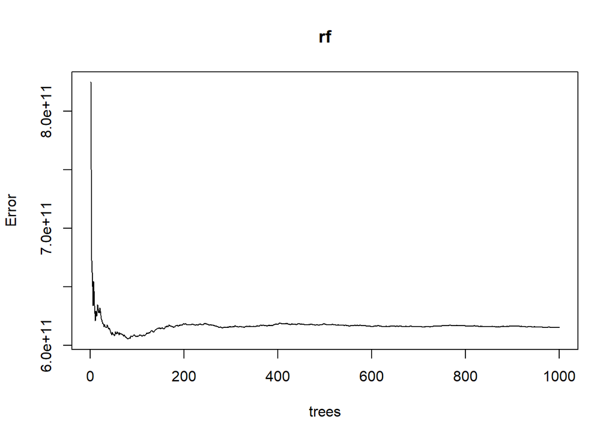

```r
plot(rf)
```

```r
summary(rf)
```

```
##                 Length Class  Mode
## call                5  -none- call
## type                1  -none- character
## predicted       12323  -none- numeric
## mse              1000  -none- numeric
## rsq              1000  -none- numeric
## oob.times       12323  -none- numeric
## importance          3  -none- numeric
## importanceSD        0  -none- NULL
## localImportance     0  -none- NULL
## proximity           0  -none- NULL
## ntree               1  -none- numeric
## mtry                1  -none- numeric
## forest             11  -none- list
## coefs               0  -none- NULL
## y               12323  -none- numeric
## test                0  -none- NULL
## inbag               0  -none- NULL
## terms               3  terms  call
```

Este modelo no permite la interpretación de parámetros.

### Conclusión

En terminos generales se observa que la variable que más influye en el modelo son los años de escolaridad, aumentando en promedio 160000 CLP el ingreso por cada año adicional de escolaridad. La edad de cada persona no influye tanto en el ingreso de las personas, aumentando en 13000 CLP en promedio por cada año más de edad.

Finalmente la variable dummy Sexo, no ayudó a mejorar el rendimieto del algoritmo, ya que los parámetros e indicadores se mantuvieron prácticamente iguales, pero si ayudó a cuantificar la brecha salarial sufrida por el sexo femenino con un promedio de 255000 CLP menos que el sueldo percibido por el sexo masculino.